# IE582-Assignment 1

Deniz Sezin Ayvaz - IE582 - Fall 2018

17 October 2018

**TASK 1**

1. First I took only the unique rows from matches data. Then I transformed the date information to year-month-day format. I splitted the score column data into two: home goals and away goals. Then I summed them up to fin the total goals. Then I structured a clumn named isOver, which shows if the match ended with total goals more than 2 (to cope up with our threshold level=2.5). I filtered the odd data with threshold=2.5 and bettype=over/under. I ordered the data with respect to matchId, oddtype,bookmaker,date and took the first odd value as the initial odd given by the bookmaker, the last odd value as the final odd. 1/odd is the probability, and to normalize those probabilites, I divided the over probabilites to the sum of over and under probabilities.

I chose Pinnacle, Betsson, youwin, Betway and bwin as 5 bookmakers. I structured bins with 0.05 bin width for probabilites.I merged bins which have less than 5 data points, to the bins that have more datapoints. Empirical over is calculated as mean of the fraction of matches that ended as over in tat bin and probabilistic over as mean of the over probabilities in that bin.

I plotted graphs for final and initial odds for each bookmaker. By looking at the graphs, overall, final odds do a better job in estimating the result, because points gather more around the x=y line. Out of the bookmakers I chose, bwin and Betsson seem to set better odds.

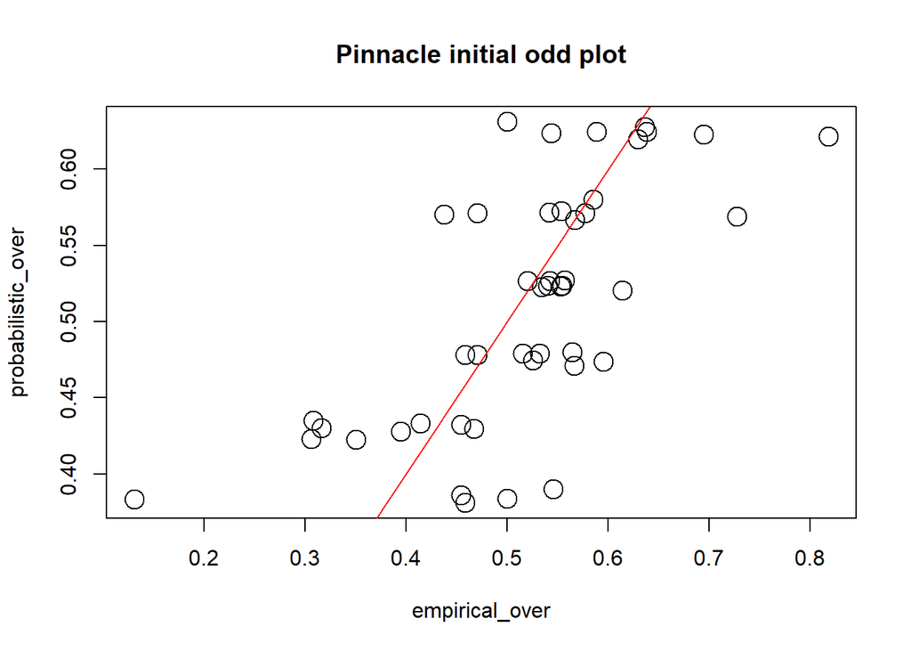

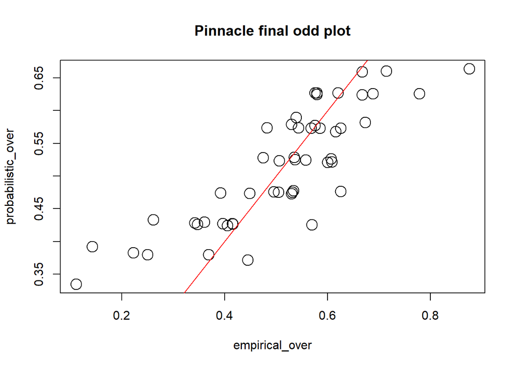

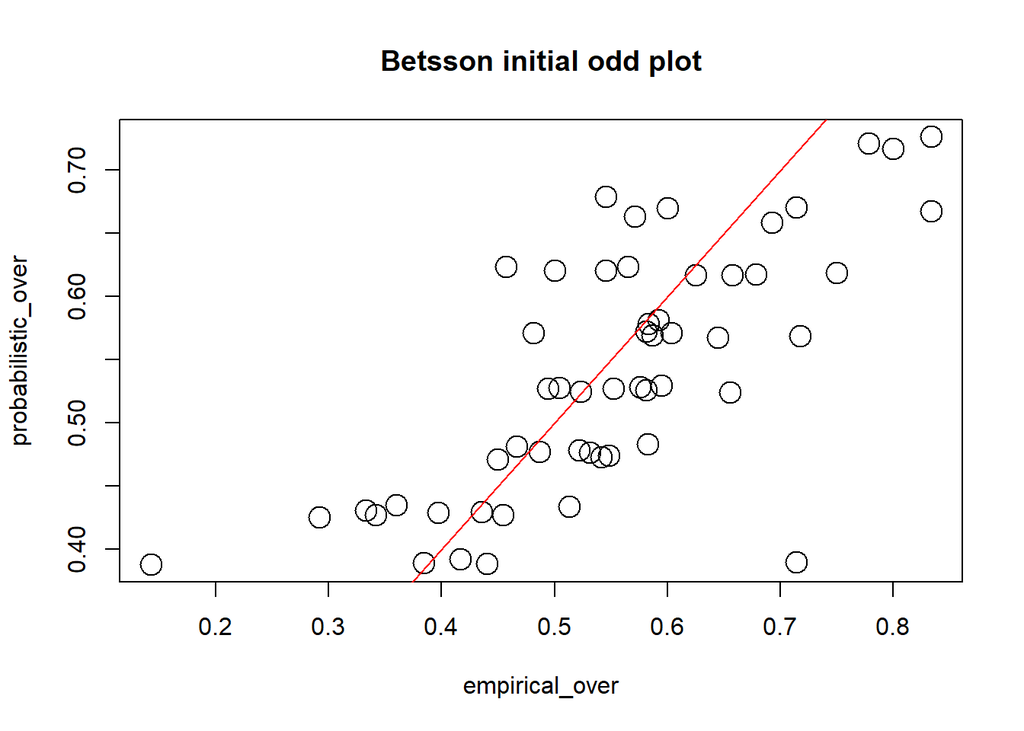

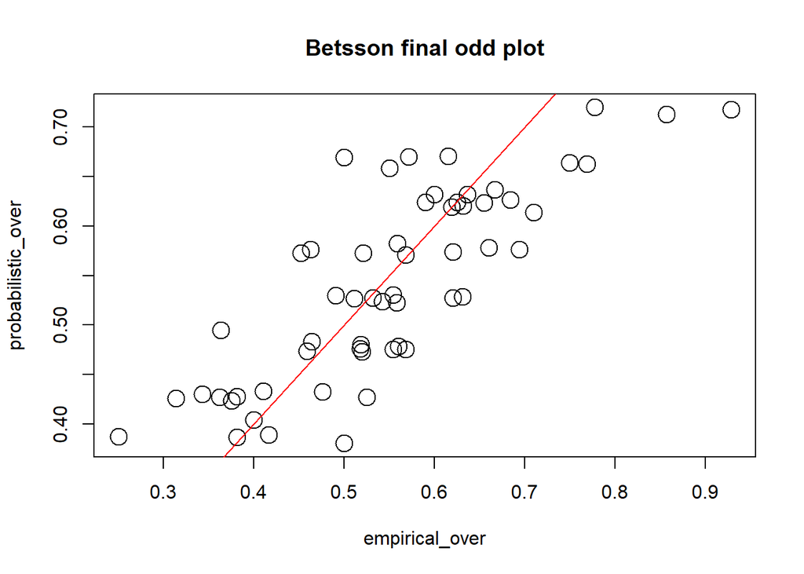

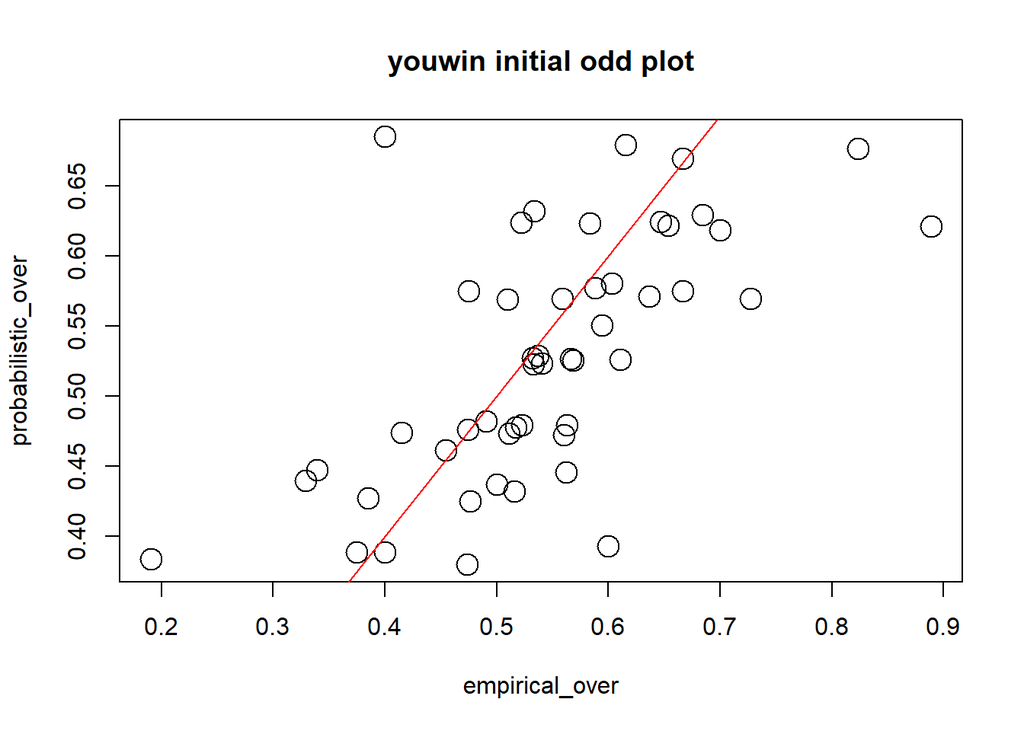

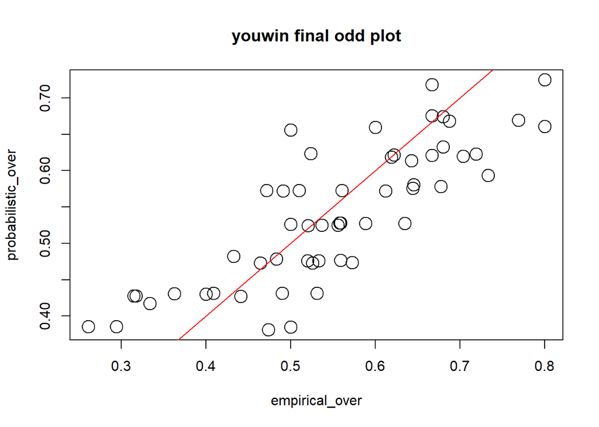

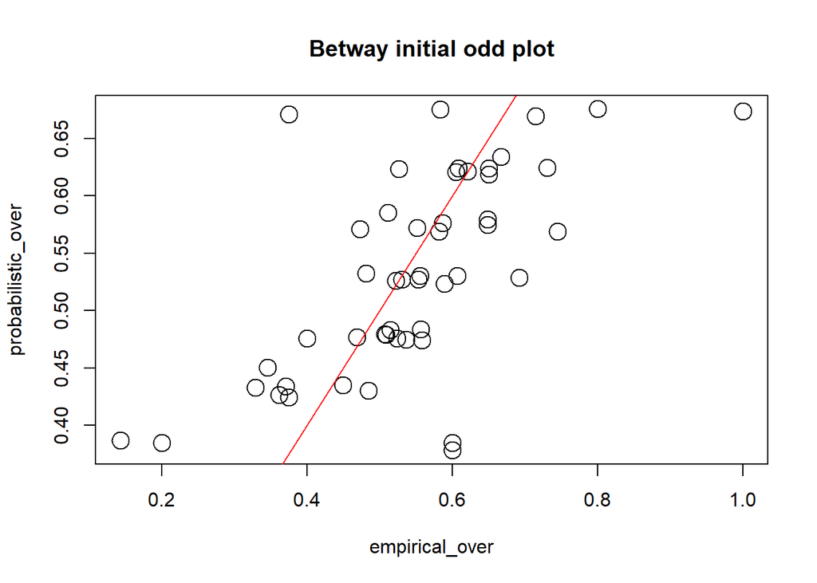

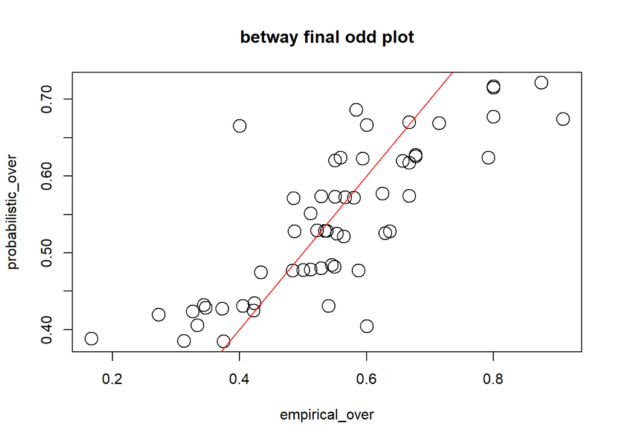

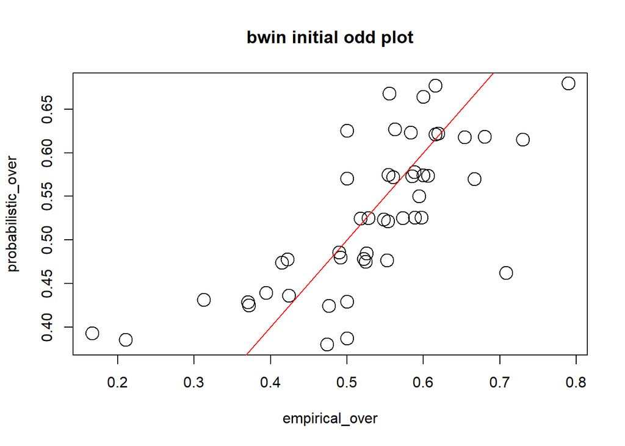

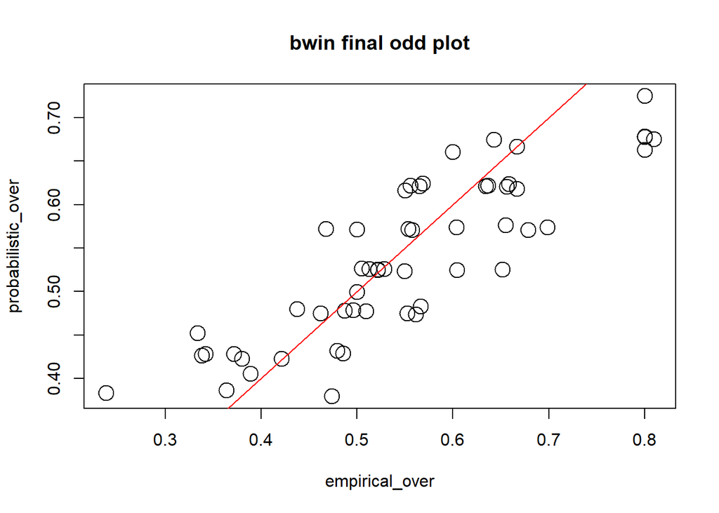

2. I chose bwin as the bookmaker. It seems like the bookmaker tends to keep the over odds the same over the years. But it usually doesn’t keep up with the variating match scores.

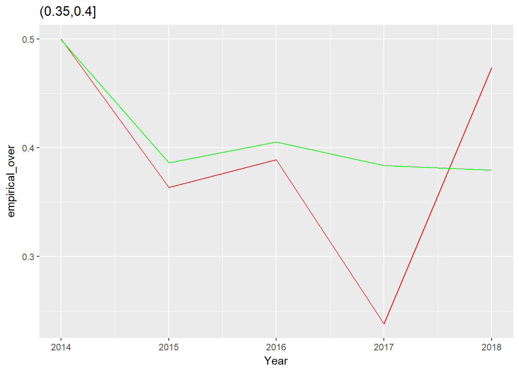

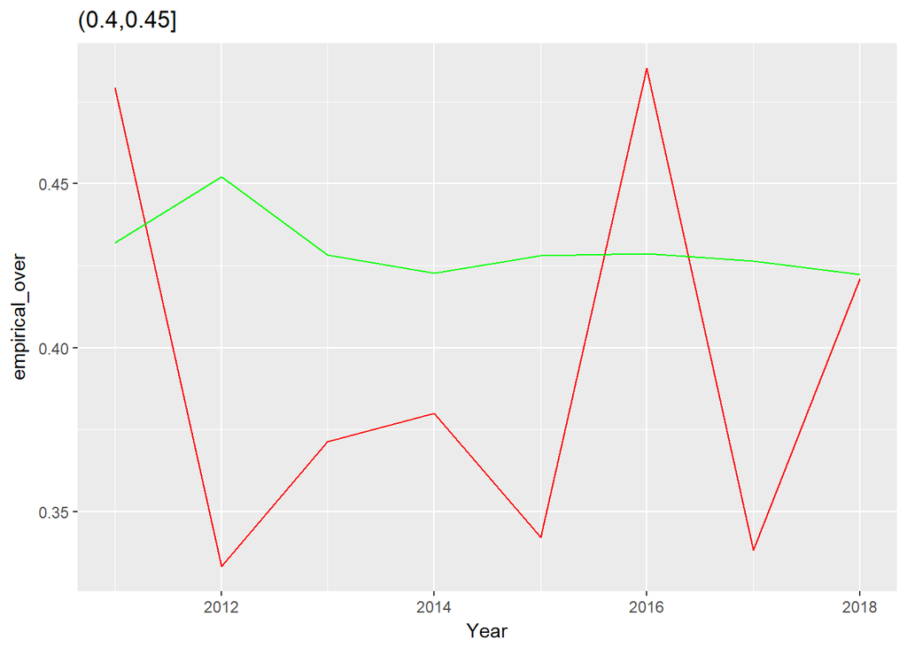

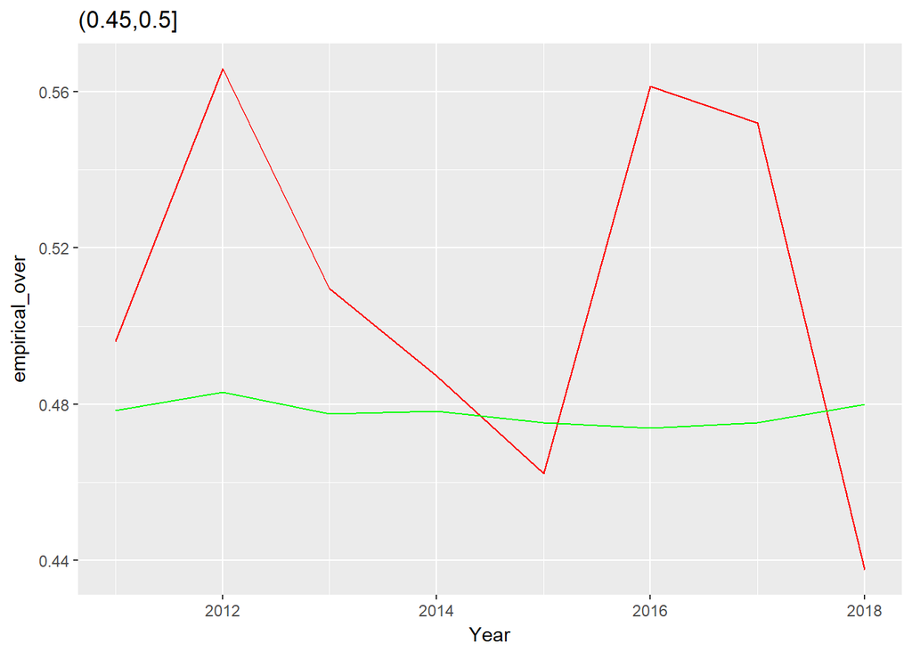

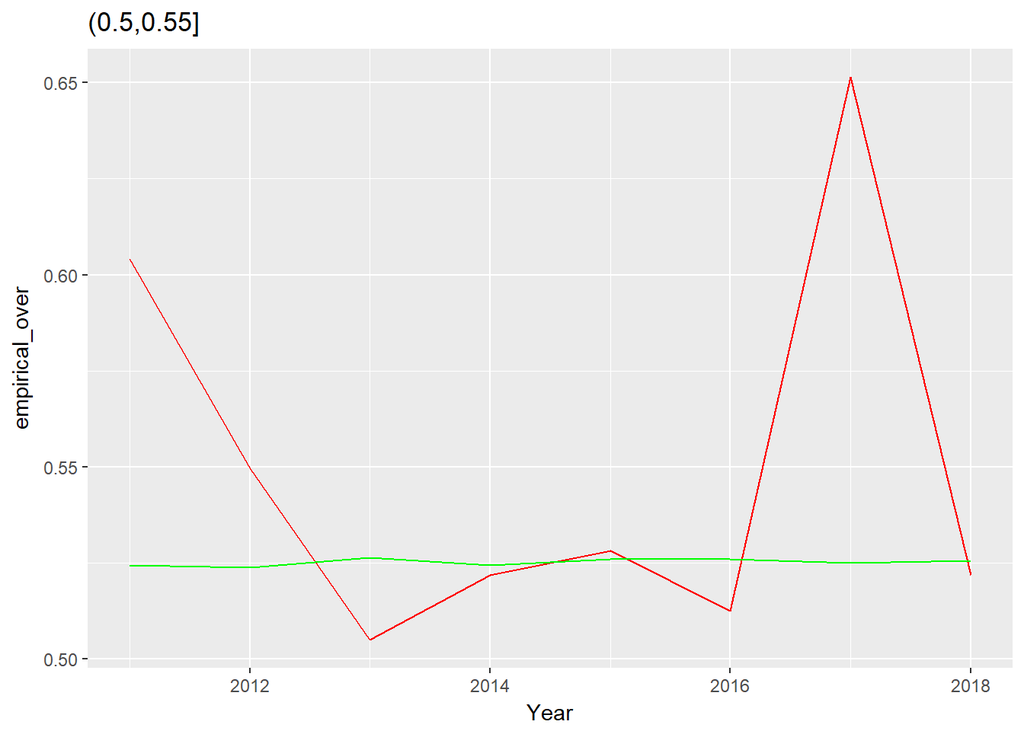

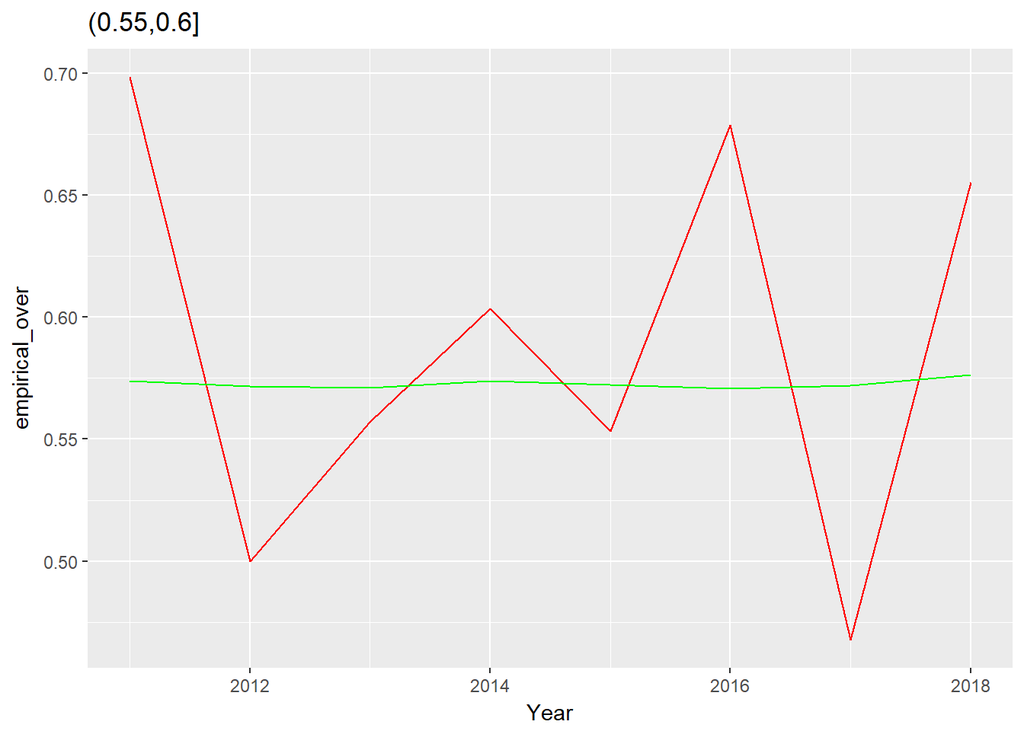

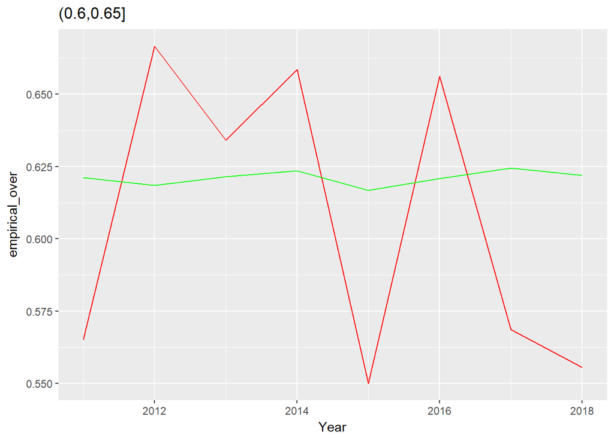

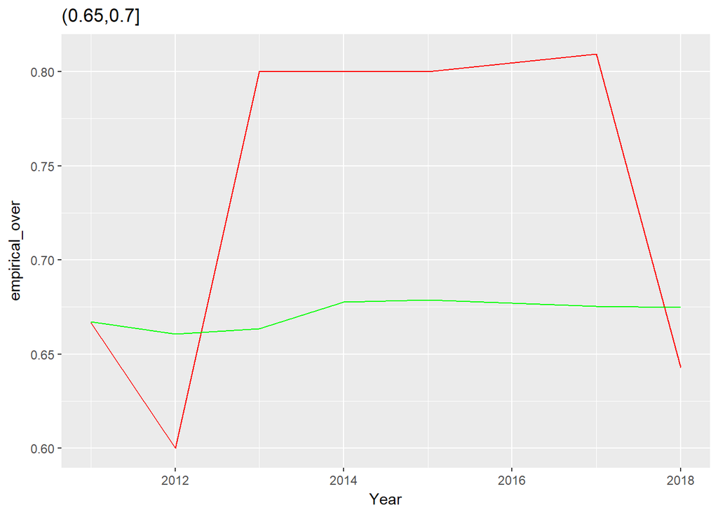

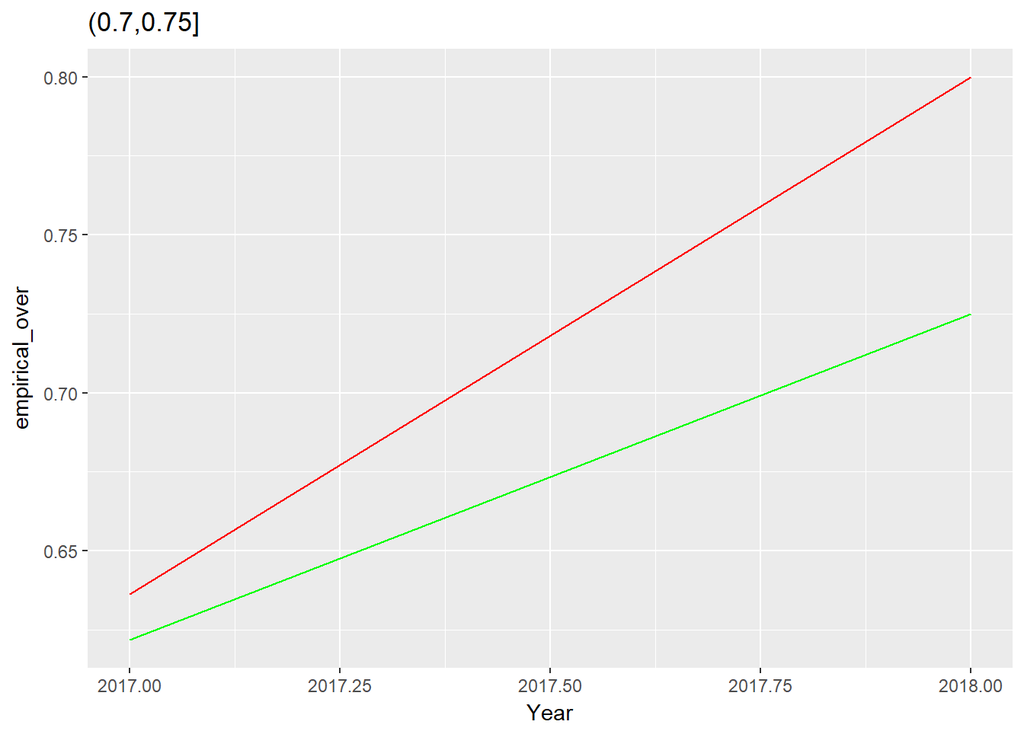

**TASK 2**

I chose to show different lines for different odd types. This way we can see how a bookmaker changed a “home win” odd in time for a specific match, for example. (chosen bookmaker: Pinnacle) It seems like the bookmaker changes the “away win” odd more than the other odd types.

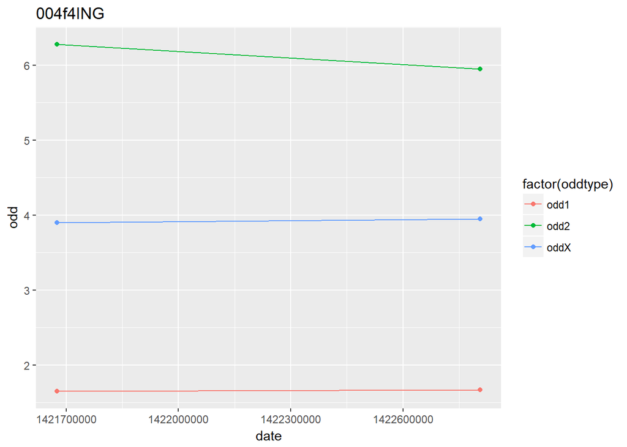

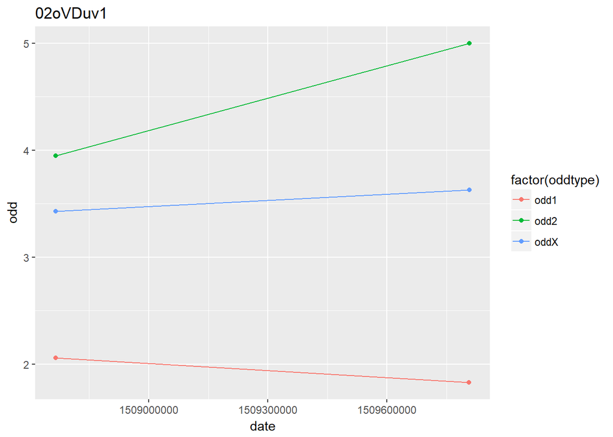

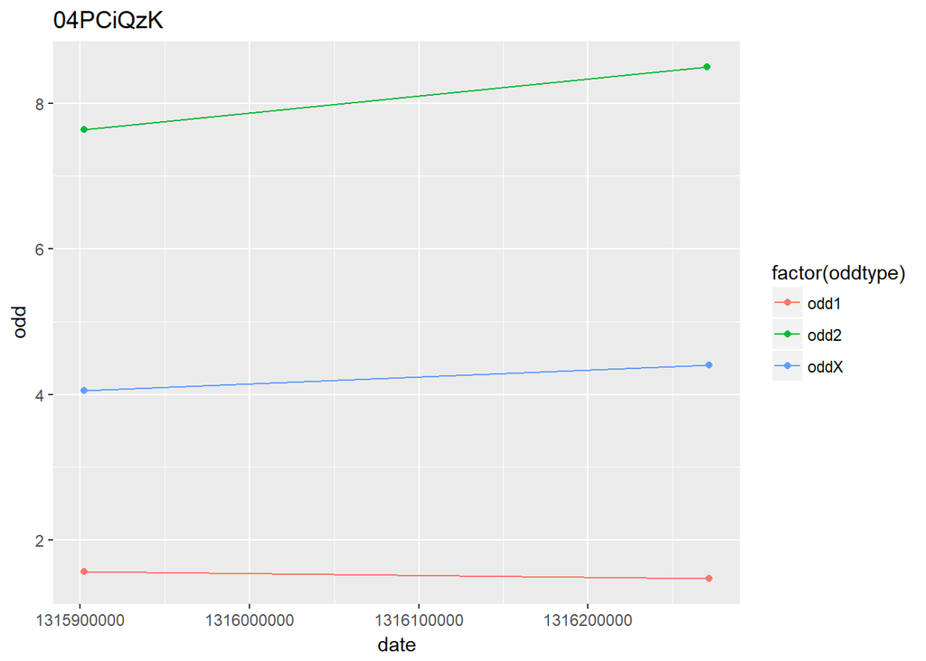

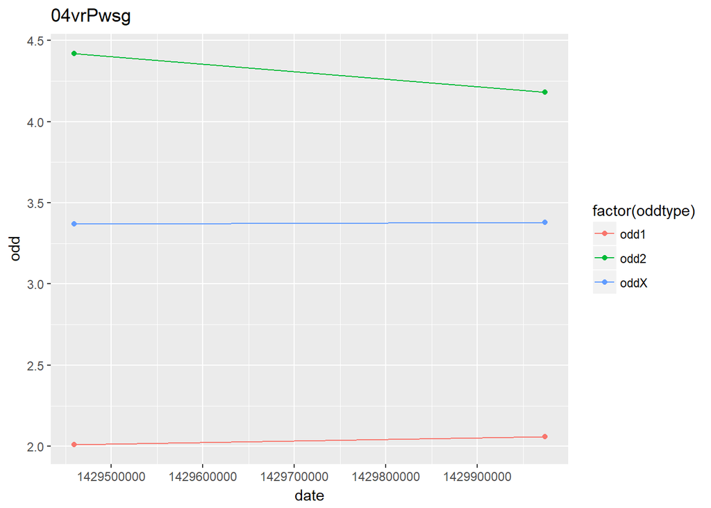

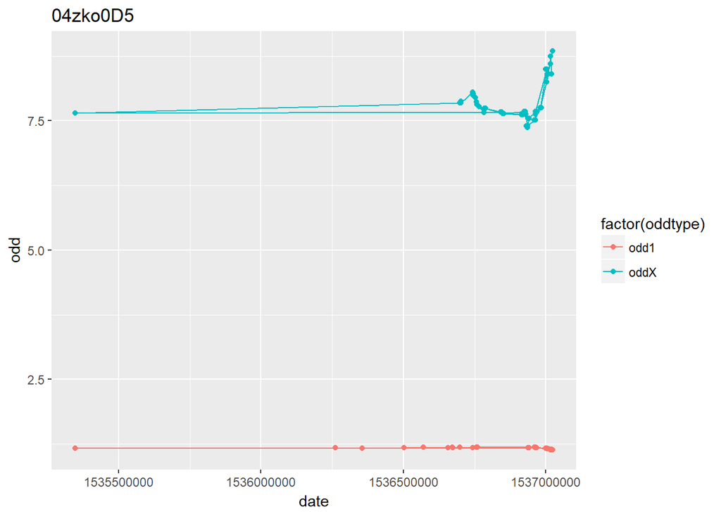

**APPENDIX**

R Code:

require(data.table) require(anytime) require(dplyr) setwd(“C:/Users/sayvaz/Desktop”)

matches=readRDS(“df9b1196-e3cf-4cc7-9159-f236fe738215_matches.rds”)

odd_details=readRDS(“df9b1196-e3cf-4cc7-9159-f236fe738215_odd_details.rds”)

matches=unique(matches)

#transform unix time to date time matches[,match_time:=anytime(date)]

matches[,c(“HomeGoals”,“AwayGoals”):=tstrsplit(score,‘:’)]

matches[,Year:=year(match_time)]

#transform characters to numeric for scores matches$HomeGoals=as.numeric(matches$HomeGoals) matches[,AwayGoals:=as.numeric(AwayGoals)]

#calculate total goals matches[,TotalGoals:=HomeGoals+AwayGoals]

# mark over under

matches[,IsOver:=0] matches[TotalGoals>2,IsOver:=1]

#yearly average goals yearly_goals=matches[,list(AvgGoals=mean(TotalGoals)),by=list(Year)]

#filter over under 2.5 odds_over_under=odd_details[betType==‘ou’ & totalhandicap==‘2.5’]

#order data in ascending date odds_over_under=odds_over_under[order(matchId, oddtype,bookmaker,date)]

odds_over_under_initial=odds_over_under[,list(start_odd=odd[1]), by=list(matchId,oddtype,bookmaker)]

odds_over_under_final=odds_over_under[,list(final_odd=odd[.N]), by=list(matchId,oddtype,bookmaker)]

#get pinnacle initial over under odds pinnacle_over_under=odds_over_under_initial[bookmaker==‘Pinnacle’]

pinnacle_wide=dcast(pinnacle_over_under, matchId~oddtype, value.var=‘start_odd’)

# join odds with matches

merged_matches=merge(matches,pinnacle_wide,by=‘matchId’)

merged_matches[,probOver:=1/over] merged_matches[,probUnder:=1/under]

merged_matches[,totalProb:=probOver+probUnder]

merged_matches[,probOver:=probOver/totalProb] merged_matches[,probUnder:=probUnder/totalProb]

merged_matches=merged_matches[complete.cases(merged_matches)] merged_matches[,totalProb:=NULL]

cutpoints=seq(0,1,0.05) merged_matches[,odd_cut_over:=cut(probOver,cutpoints)]

summary_table=merged_matches[,list(empirical_over=mean(IsOver), probabilistic_over=mean(probOver),.N), by=list(Year,odd_cut_over)]

summary_table=summary_table[order(Year,odd_cut_over)]

#merge bins temp<-c() k<-1 for(i in 1:nrow(summary_table)){ if(summary_table$N[i]<5){ if(summary_table$Year[i]==summary_table$Year[i-1]){ summary_table$empirical_over[i-1]<-(summary_table$N[i]*summary_table$empirical_over[i]+summary_table$N[i-1]*summary_table$empirical_over[i-1])/(summary_table$N[i]+summary_table$N[i-1]) summary_table$probabilistic_over[i-1]<-(summary_table$N[i]*summary_table$probabilistic_over[i]+summary_table$N[i-1]*summary_table$probabilistic_over[i-1])/(summary_table$N[i]+summary_table$N[i-1]) summary_table$N[i-1]<-summary_table$N[i-1]+summary_table$N[i] temp[k]<-i k<-k+1 }else{ summary_table$empirical_over[i+1]<-(summary_table$N[i]*summary_table$empirical_over[i]+summary_table$N[i+1]*summary_table$empirical_over[i+1])/(summary_table$N[i]+summary_table$N[i+1]) summary_table$probabilistic_over[i+1]<-(summary_table$N[i]*summary_table$probabilistic_over[i]+summary_table$N[i+1]*summary_table$probabilistic_over[i+1])/(summary_table$N[i]+summary_table$N[i+1]) summary_table$N[i+1]<-summary_table$N[i+1]+summary_table$N[i] temp[k]<-i k<-k+1 } } } summary_table<-summary_table[-temp,]

plot(summary_table[,list(empirical_over,probabilistic_over)],cex=2,main=“Pinnacle initial odd plot”) abline(0,1,col=‘red’)

#get pinnacle final over under odds pinnacle_over_under=odds_over_under_final[bookmaker==‘Pinnacle’]

pinnacle_wide=dcast(pinnacle_over_under, matchId~oddtype, value.var=‘final_odd’)

# join odds with matches

merged_matches=merge(matches,pinnacle_wide,by=‘matchId’)

merged_matches[,probOver:=1/over] merged_matches[,probUnder:=1/under]

merged_matches[,totalProb:=probOver+probUnder]

merged_matches[,probOver:=probOver/totalProb] merged_matches[,probUnder:=probUnder/totalProb]

merged_matches=merged_matches[complete.cases(merged_matches)] merged_matches[,totalProb:=NULL]

cutpoints=seq(0,1,0.05) merged_matches[,odd_cut_over:=cut(probOver,cutpoints)]

summary_table=merged_matches[,list(empirical_over=mean(IsOver), probabilistic_over=mean(probOver),.N), by=list(Year,odd_cut_over)]

summary_table=summary_table[order(Year)]

temp<-c() k<-1 for(i in 1:nrow(summary_table)){ if(summary_table$N[i]<5){ if(summary_table$Year[i]==summary_table$Year[i-1]){ summary_table$empirical_over[i-1]<-(summary_table$N[i]*summary_table$empirical_over[i]+summary_table$N[i-1]*summary_table$empirical_over[i-1])/(summary_table$N[i]+summary_table$N[i-1]) summary_table$probabilistic_over[i-1]<-(summary_table$N[i]*summary_table$probabilistic_over[i]+summary_table$N[i-1]*summary_table$probabilistic_over[i-1])/(summary_table$N[i]+summary_table$N[i-1]) summary_table$N[i-1]<-summary_table$N[i-1]+summary_table$N[i] temp[k]<-i k<-k+1 }else{ summary_table$empirical_over[i+1]<-(summary_table$N[i]*summary_table$empirical_over[i]+summary_table$N[i+1]*summary_table$empirical_over[i+1])/(summary_table$N[i]+summary_table$N[i+1]) summary_table$probabilistic_over[i+1]<-(summary_table$N[i]*summary_table$probabilistic_over[i]+summary_table$N[i+1]*summary_table$probabilistic_over[i+1])/(summary_table$N[i]+summary_table$N[i+1]) summary_table$N[i+1]<-summary_table$N[i+1]+summary_table$N[i] temp[k]<-i k<-k+1 } } } summary_table<-summary_table[-temp,]

plot(summary_table[,list(empirical_over,probabilistic_over)],cex=2,main=“Pinnacle final odd plot”) abline(0,1,col=‘red’)

#get betsson initial over under odds betsson_over_under=odds_over_under_initial[bookmaker==‘Betsson’]

betsson_wide=dcast(betsson_over_under, matchId~oddtype, value.var=‘start_odd’)

# join odds with matches

merged_matches=merge(matches,betsson_wide,by=‘matchId’)

merged_matches[,probOver:=1/over] merged_matches[,probUnder:=1/under]

merged_matches[,totalProb:=probOver+probUnder]

merged_matches[,probOver:=probOver/totalProb] merged_matches[,probUnder:=probUnder/totalProb]

merged_matches=merged_matches[complete.cases(merged_matches)] merged_matches[,totalProb:=NULL]

cutpoints=seq(0,1,0.05) merged_matches[,odd_cut_over:=cut(probOver,cutpoints)]

summary_table=merged_matches[,list(empirical_over=mean(IsOver), probabilistic_over=mean(probOver),.N), by=list(Year,odd_cut_over)]

summary_table=summary_table[order(Year)]

temp<-c() k<-1 for(i in 1:nrow(summary_table)){ if(summary_table$N[i]<5){ if(summary_table$Year[i]==summary_table$Year[i-1]){ summary_table$empirical_over[i-1]<-(summary_table$N[i]*summary_table$empirical_over[i]+summary_table$N[i-1]*summary_table$empirical_over[i-1])/(summary_table$N[i]+summary_table$N[i-1]) summary_table$probabilistic_over[i-1]<-(summary_table$N[i]*summary_table$probabilistic_over[i]+summary_table$N[i-1]*summary_table$probabilistic_over[i-1])/(summary_table$N[i]+summary_table$N[i-1]) summary_table$N[i-1]<-summary_table$N[i-1]+summary_table$N[i] temp[k]<-i k<-k+1 }else{ summary_table$empirical_over[i+1]<-(summary_table$N[i]*summary_table$empirical_over[i]+summary_table$N[i+1]*summary_table$empirical_over[i+1])/(summary_table$N[i]+summary_table$N[i+1]) summary_table$probabilistic_over[i+1]<-(summary_table$N[i]*summary_table$probabilistic_over[i]+summary_table$N[i+1]*summary_table$probabilistic_over[i+1])/(summary_table$N[i]+summary_table$N[i+1]) summary_table$N[i+1]<-summary_table$N[i+1]+summary_table$N[i] temp[k]<-i k<-k+1 } } } summary_table<-summary_table[-temp,]

plot(summary_table[,list(empirical_over,probabilistic_over)],cex=2,main=“Betsson initial odd plot”) abline(0,1,col=‘red’)

#get betsson final over under odds betsson_over_under=odds_over_under_final[bookmaker==‘Betsson’]

betsson_wide=dcast(betsson_over_under, matchId~oddtype, value.var=‘final_odd’)

# join odds with matches

merged_matches=merge(matches,betsson_wide,by=‘matchId’)

merged_matches[,probOver:=1/over] merged_matches[,probUnder:=1/under]

merged_matches[,totalProb:=probOver+probUnder]

merged_matches[,probOver:=probOver/totalProb] merged_matches[,probUnder:=probUnder/totalProb]

merged_matches=merged_matches[complete.cases(merged_matches)] merged_matches[,totalProb:=NULL]

cutpoints=seq(0,1,0.05) merged_matches[,odd_cut_over:=cut(probOver,cutpoints)]

summary_table=merged_matches[,list(empirical_over=mean(IsOver), probabilistic_over=mean(probOver),.N), by=list(Year,odd_cut_over)]

summary_table=summary_table[order(Year)]

temp<-c() k<-1 for(i in 1:nrow(summary_table)){ if(summary_table$N[i]<5){ if(summary_table$Year[i]==summary_table$Year[i-1]){ summary_table$empirical_over[i-1]<-(summary_table$N[i]*summary_table$empirical_over[i]+summary_table$N[i-1]*summary_table$empirical_over[i-1])/(summary_table$N[i]+summary_table$N[i-1]) summary_table$probabilistic_over[i-1]<-(summary_table$N[i]*summary_table$probabilistic_over[i]+summary_table$N[i-1]*summary_table$probabilistic_over[i-1])/(summary_table$N[i]+summary_table$N[i-1]) summary_table$N[i-1]<-summary_table$N[i-1]+summary_table$N[i] temp[k]<-i k<-k+1 }else{ summary_table$empirical_over[i+1]<-(summary_table$N[i]*summary_table$empirical_over[i]+summary_table$N[i+1]*summary_table$empirical_over[i+1])/(summary_table$N[i]+summary_table$N[i+1]) summary_table$probabilistic_over[i+1]<-(summary_table$N[i]*summary_table$probabilistic_over[i]+summary_table$N[i+1]*summary_table$probabilistic_over[i+1])/(summary_table$N[i]+summary_table$N[i+1]) summary_table$N[i+1]<-summary_table$N[i+1]+summary_table$N[i] temp[k]<-i k<-k+1 } } } summary_table<-summary_table[-temp,]

plot(summary_table[,list(empirical_over,probabilistic_over)],cex=2,main=“Betsson final odd plot”) abline(0,1,col=‘red’)

#get youwin initial over under odds youwin_over_under=odds_over_under_initial[bookmaker==‘youwin’]

youwin_wide=dcast(youwin_over_under, matchId~oddtype, value.var=‘start_odd’)

# join odds with matches

merged_matches=merge(matches,youwin_wide,by=‘matchId’)

merged_matches[,probOver:=1/over] merged_matches[,probUnder:=1/under]

merged_matches[,totalProb:=probOver+probUnder]

merged_matches[,probOver:=probOver/totalProb] merged_matches[,probUnder:=probUnder/totalProb]

merged_matches=merged_matches[complete.cases(merged_matches)] merged_matches[,totalProb:=NULL]

cutpoints=seq(0,1,0.05) merged_matches[,odd_cut_over:=cut(probOver,cutpoints)]

summary_table=merged_matches[,list(empirical_over=mean(IsOver), probabilistic_over=mean(probOver),.N), by=list(Year,odd_cut_over)]

summary_table=summary_table[order(Year)]

temp<-c() k<-1 for(i in 1:nrow(summary_table)){ if(summary_table$N[i]<5){ if(summary_table$Year[i]==summary_table$Year[i-1]){ summary_table$empirical_over[i-1]<-(summary_table$N[i]*summary_table$empirical_over[i]+summary_table$N[i-1]*summary_table$empirical_over[i-1])/(summary_table$N[i]+summary_table$N[i-1]) summary_table$probabilistic_over[i-1]<-(summary_table$N[i]*summary_table$probabilistic_over[i]+summary_table$N[i-1]*summary_table$probabilistic_over[i-1])/(summary_table$N[i]+summary_table$N[i-1]) summary_table$N[i-1]<-summary_table$N[i-1]+summary_table$N[i] temp[k]<-i k<-k+1 }else{ summary_table$empirical_over[i+1]<-(summary_table$N[i]*summary_table$empirical_over[i]+summary_table$N[i+1]*summary_table$empirical_over[i+1])/(summary_table$N[i]+summary_table$N[i+1]) summary_table$probabilistic_over[i+1]<-(summary_table$N[i]*summary_table$probabilistic_over[i]+summary_table$N[i+1]*summary_table$probabilistic_over[i+1])/(summary_table$N[i]+summary_table$N[i+1]) summary_table$N[i+1]<-summary_table$N[i+1]+summary_table$N[i] temp[k]<-i k<-k+1 } } } summary_table<-summary_table[-temp,]

plot(summary_table[,list(empirical_over,probabilistic_over)],cex=2,main=“youwin initial odd plot”) abline(0,1,col=‘red’)

#get youwin final over under odds youwin_over_under=odds_over_under_final[bookmaker==‘youwin’]

youwin_wide=dcast(youwin_over_under, matchId~oddtype, value.var=‘final_odd’)

# join odds with matches

merged_matches=merge(matches,youwin_wide,by=‘matchId’)

merged_matches[,probOver:=1/over] merged_matches[,probUnder:=1/under]

merged_matches[,totalProb:=probOver+probUnder]

merged_matches[,probOver:=probOver/totalProb] merged_matches[,probUnder:=probUnder/totalProb]

merged_matches=merged_matches[complete.cases(merged_matches)] merged_matches[,totalProb:=NULL]

cutpoints=seq(0,1,0.05) merged_matches[,odd_cut_over:=cut(probOver,cutpoints)]

summary_table=merged_matches[,list(empirical_over=mean(IsOver), probabilistic_over=mean(probOver),.N), by=list(Year,odd_cut_over)]

summary_table=summary_table[order(Year)]

temp<-c() k<-1 for(i in 1:nrow(summary_table)){ if(summary_table$N[i]<5){ if(summary_table$Year[i]==summary_table$Year[i-1]){ summary_table$empirical_over[i-1]<-(summary_table$N[i]*summary_table$empirical_over[i]+summary_table$N[i-1]*summary_table$empirical_over[i-1])/(summary_table$N[i]+summary_table$N[i-1]) summary_table$probabilistic_over[i-1]<-(summary_table$N[i]*summary_table$probabilistic_over[i]+summary_table$N[i-1]*summary_table$probabilistic_over[i-1])/(summary_table$N[i]+summary_table$N[i-1]) summary_table$N[i-1]<-summary_table$N[i-1]+summary_table$N[i] temp[k]<-i k<-k+1 }else{ summary_table$empirical_over[i+1]<-(summary_table$N[i]*summary_table$empirical_over[i]+summary_table$N[i+1]*summary_table$empirical_over[i+1])/(summary_table$N[i]+summary_table$N[i+1]) summary_table$probabilistic_over[i+1]<-(summary_table$N[i]*summary_table$probabilistic_over[i]+summary_table$N[i+1]*summary_table$probabilistic_over[i+1])/(summary_table$N[i]+summary_table$N[i+1]) summary_table$N[i+1]<-summary_table$N[i+1]+summary_table$N[i] temp[k]<-i k<-k+1 } } } summary_table<-summary_table[-temp,]

plot(summary_table[,list(empirical_over,probabilistic_over)],cex=2,main=“youwin final odd plot”) abline(0,1,col=‘red’)

#get betway initial over under odds betway_over_under=odds_over_under_initial[bookmaker==‘Betway’]

betway_wide=dcast(betway_over_under, matchId~oddtype, value.var=‘start_odd’)

# join odds with matches

merged_matches=merge(matches,betway_wide,by=‘matchId’)

merged_matches[,probOver:=1/over] merged_matches[,probUnder:=1/under]

merged_matches[,totalProb:=probOver+probUnder]

merged_matches[,probOver:=probOver/totalProb] merged_matches[,probUnder:=probUnder/totalProb]

merged_matches=merged_matches[complete.cases(merged_matches)] merged_matches[,totalProb:=NULL]

cutpoints=seq(0,1,0.05) merged_matches[,odd_cut_over:=cut(probOver,cutpoints)]

summary_table=merged_matches[,list(empirical_over=mean(IsOver), probabilistic_over=mean(probOver),.N), by=list(Year,odd_cut_over)]

summary_table=summary_table[order(Year)]

temp<-c() k<-1 for(i in 1:nrow(summary_table)){ if(summary_table$N[i]<5){ if(summary_table$Year[i]==summary_table$Year[i-1]){ summary_table$empirical_over[i-1]<-(summary_table$N[i]*summary_table$empirical_over[i]+summary_table$N[i-1]*summary_table$empirical_over[i-1])/(summary_table$N[i]+summary_table$N[i-1]) summary_table$probabilistic_over[i-1]<-(summary_table$N[i]*summary_table$probabilistic_over[i]+summary_table$N[i-1]*summary_table$probabilistic_over[i-1])/(summary_table$N[i]+summary_table$N[i-1]) summary_table$N[i-1]<-summary_table$N[i-1]+summary_table$N[i] temp[k]<-i k<-k+1 }else{ summary_table$empirical_over[i+1]<-(summary_table$N[i]*summary_table$empirical_over[i]+summary_table$N[i+1]*summary_table$empirical_over[i+1])/(summary_table$N[i]+summary_table$N[i+1]) summary_table$probabilistic_over[i+1]<-(summary_table$N[i]*summary_table$probabilistic_over[i]+summary_table$N[i+1]*summary_table$probabilistic_over[i+1])/(summary_table$N[i]+summary_table$N[i+1]) summary_table$N[i+1]<-summary_table$N[i+1]+summary_table$N[i] temp[k]<-i k<-k+1 } } } summary_table<-summary_table[-temp,]

plot(summary_table[,list(empirical_over,probabilistic_over)],cex=2,main=“Betway initial odd plot”) abline(0,1,col=‘red’)

#get betway final over under odds betway_over_under=odds_over_under_final[bookmaker==‘Betway’]

betway_wide=dcast(betway_over_under, matchId~oddtype, value.var=‘final_odd’)

# join odds with matches

merged_matches=merge(matches,betway_wide,by=‘matchId’)

merged_matches[,probOver:=1/over] merged_matches[,probUnder:=1/under]

merged_matches[,totalProb:=probOver+probUnder]

merged_matches[,probOver:=probOver/totalProb] merged_matches[,probUnder:=probUnder/totalProb]

merged_matches=merged_matches[complete.cases(merged_matches)] merged_matches[,totalProb:=NULL]

cutpoints=seq(0,1,0.05) merged_matches[,odd_cut_over:=cut(probOver,cutpoints)]

summary_table=merged_matches[,list(empirical_over=mean(IsOver), probabilistic_over=mean(probOver),.N), by=list(Year,odd_cut_over)]

summary_table=summary_table[order(Year)]

temp<-c() k<-1 for(i in 1:nrow(summary_table)){ if(summary_table$N[i]<5){ if(summary_table$Year[i]==summary_table$Year[i-1]){ summary_table$empirical_over[i-1]<-(summary_table$N[i]*summary_table$empirical_over[i]+summary_table$N[i-1]*summary_table$empirical_over[i-1])/(summary_table$N[i]+summary_table$N[i-1]) summary_table$probabilistic_over[i-1]<-(summary_table$N[i]*summary_table$probabilistic_over[i]+summary_table$N[i-1]*summary_table$probabilistic_over[i-1])/(summary_table$N[i]+summary_table$N[i-1]) summary_table$N[i-1]<-summary_table$N[i-1]+summary_table$N[i] temp[k]<-i k<-k+1 }else{ summary_table$empirical_over[i+1]<-(summary_table$N[i]*summary_table$empirical_over[i]+summary_table$N[i+1]*summary_table$empirical_over[i+1])/(summary_table$N[i]+summary_table$N[i+1]) summary_table$probabilistic_over[i+1]<-(summary_table$N[i]*summary_table$probabilistic_over[i]+summary_table$N[i+1]*summary_table$probabilistic_over[i+1])/(summary_table$N[i]+summary_table$N[i+1]) summary_table$N[i+1]<-summary_table$N[i+1]+summary_table$N[i] temp[k]<-i k<-k+1 } } } summary_table<-summary_table[-temp,]

plot(summary_table[,list(empirical_over,probabilistic_over)],cex=2,main=“betway final odd plot”) abline(0,1,col=‘red’)

#get bwin initial over under odds bwin_over_under=odds_over_under_initial[bookmaker==‘bwin’]

bwin_wide=dcast(bwin_over_under, matchId~oddtype, value.var=‘start_odd’)

# join odds with matches

merged_matches=merge(matches,bwin_wide,by=‘matchId’)

merged_matches[,probOver:=1/over] merged_matches[,probUnder:=1/under]

merged_matches[,totalProb:=probOver+probUnder]

merged_matches[,probOver:=probOver/totalProb] merged_matches[,probUnder:=probUnder/totalProb]

merged_matches=merged_matches[complete.cases(merged_matches)] merged_matches[,totalProb:=NULL]

cutpoints=seq(0,1,0.05) merged_matches[,odd_cut_over:=cut(probOver,cutpoints)]

summary_table=merged_matches[,list(empirical_over=mean(IsOver), probabilistic_over=mean(probOver),.N), by=list(Year,odd_cut_over)]

summary_table=summary_table[order(Year)]

temp<-c() k<-1 for(i in 1:nrow(summary_table)){ if(summary_table$N[i]<5){ if(summary_table$Year[i]==summary_table$Year[i-1]){ summary_table$empirical_over[i-1]<-(summary_table$N[i]*summary_table$empirical_over[i]+summary_table$N[i-1]*summary_table$empirical_over[i-1])/(summary_table$N[i]+summary_table$N[i-1]) summary_table$probabilistic_over[i-1]<-(summary_table$N[i]*summary_table$probabilistic_over[i]+summary_table$N[i-1]*summary_table$probabilistic_over[i-1])/(summary_table$N[i]+summary_table$N[i-1]) summary_table$N[i-1]<-summary_table$N[i-1]+summary_table$N[i] temp[k]<-i k<-k+1 }else{ summary_table$empirical_over[i+1]<-(summary_table$N[i]*summary_table$empirical_over[i]+summary_table$N[i+1]*summary_table$empirical_over[i+1])/(summary_table$N[i]+summary_table$N[i+1]) summary_table$probabilistic_over[i+1]<-(summary_table$N[i]*summary_table$probabilistic_over[i]+summary_table$N[i+1]*summary_table$probabilistic_over[i+1])/(summary_table$N[i]+summary_table$N[i+1]) summary_table$N[i+1]<-summary_table$N[i+1]+summary_table$N[i] temp[k]<-i k<-k+1 } } } summary_table<-summary_table[-temp,]

plot(summary_table[,list(empirical_over,probabilistic_over)],cex=2,main=“bwin initial odd plot”) abline(0,1,col=‘red’)

#get bwin final over under odds bwin_over_under=odds_over_under_final[bookmaker==‘bwin’]

bwin_wide=dcast(bwin_over_under, matchId~oddtype, value.var=‘final_odd’)

# join odds with matches

merged_matches=merge(matches,bwin_wide,by=‘matchId’)

merged_matches[,probOver:=1/over] merged_matches[,probUnder:=1/under]

merged_matches[,totalProb:=probOver+probUnder]

merged_matches[,probOver:=probOver/totalProb] merged_matches[,probUnder:=probUnder/totalProb]

merged_matches=merged_matches[complete.cases(merged_matches)] merged_matches[,totalProb:=NULL]

cutpoints=seq(0,1,0.05) merged_matches[,odd_cut_over:=cut(probOver,cutpoints)]

summary_table=merged_matches[,list(empirical_over=mean(IsOver), probabilistic_over=mean(probOver),.N), by=list(Year,odd_cut_over)]

summary_table=summary_table[order(Year)]

temp<-c() k<-1 for(i in 1:nrow(summary_table)){ if(summary_table$N[i]<5){ if(summary_table$Year[i]==summary_table$Year[i-1]){ summary_table$empirical_over[i-1]<-(summary_table$N[i]*summary_table$empirical_over[i]+summary_table$N[i-1]*summary_table$empirical_over[i-1])/(summary_table$N[i]+summary_table$N[i-1]) summary_table$probabilistic_over[i-1]<-(summary_table$N[i]*summary_table$probabilistic_over[i]+summary_table$N[i-1]*summary_table$probabilistic_over[i-1])/(summary_table$N[i]+summary_table$N[i-1]) summary_table$N[i-1]<-summary_table$N[i-1]+summary_table$N[i] temp[k]<-i k<-k+1 }else{ summary_table$empirical_over[i+1]<-(summary_table$N[i]*summary_table$empirical_over[i]+summary_table$N[i+1]*summary_table$empirical_over[i+1])/(summary_table$N[i]+summary_table$N[i+1]) summary_table$probabilistic_over[i+1]<-(summary_table$N[i]*summary_table$probabilistic_over[i]+summary_table$N[i+1]*summary_table$probabilistic_over[i+1])/(summary_table$N[i]+summary_table$N[i+1]) summary_table$N[i+1]<-summary_table$N[i+1]+summary_table$N[i] temp[k]<-i k<-k+1 } } } summary_table<-summary_table[-temp,]

plot(summary_table[,list(empirical_over,probabilistic_over)],cex=2,main=“bwin final odd plot”) abline(0,1,col=‘red’)

#Task1 question b

task1_b<-summary_table%>% group_by(odd_cut_over) %>% do(plots=ggplot(data=.) + aes(x=Year)+geom_line(aes(y=empirical_over),colour=“red”)+geom_line(aes(y=probabilistic_over),colour=“green”) + ggtitle(unique(.$odd_cut_over))+scale_color_manual(name = "lines", labels = c("empirical_over"="red", "probabilistic_over"="green"))) task1_b$plots

#task2

change_in_odds<-odd_details[betType==“1x2”& bookmaker==“Pinnacle”] odd_change<-change_in_odds[1:100,]

odd_change_plot<-odd_change%>%group_by(matchId)%>%do(plots=ggplot(., aes(date, odd, color = factor(oddtype)))+ geom_path() + geom_point()+ ggtitle(unique(.$matchId)))

odd_change_plot$plots